# Pandas-Bootcamp-Part4

### Extract all columns from 'vitamin b12' till the end, for the first , 2nd and 3rd rows

```python
nutr_mini.head(2)
```

| name | serving_size | calories | total_fat | saturated_fat | cholesterol | sodium | choline | folate | folic_acid | niacin | ... | fat | saturated_fatty_acids | monounsaturated_fatty_acids | polyunsaturated_fatty_acids | fatty_acids_total_trans | alcohol | ash | caffeine | theobromine | water |
| --- | --- | --- | --- | --- | --- | --- | --- | --- | --- | --- | --- | --- | --- | --- | --- | --- | --- | --- | --- | --- | --- |
| Margarine-like, with added vitamin D, with salt, tub, 60% fat, vegetable oil spread | 100 g | 533 | 60g | 12g | 1mg | 785.00 mg | 10.2 mg | 1.00 mcg | 0.00 mcg | 0.016 mg | ... | 59.81 g | 12.086 g | 19.347 g | 26.477 g | 1.00 mg | 0.0 g | 1.59 g | 0.00 mg | 0.00 mg | 37.58 g |
| Pork, pan-fried, cooked, separable lean only, bone-in, center rib (chops), loin, fresh | 100 g | 211 | 9.7g | 2.6g | 77mg | 88.00 mg | 96.6 mg | 0.00 mcg | 0.00 mcg | 9.432 mg | ... | 9.73 g | 2.563 g | 5.759 g | 1.408 g | 77.00 mg | 0.0 g | 1.29 g | 0.00 mg | 0.00 mg | 61.14 g |

2 rows × 75 columns

```python
nutr_mini.columns.get_loc('vitamin_b12')
```

```
20
```

```python
nutr_mini.iloc[[0,1,2] , 20 : ]
```

| name | vitamin_b12 | vitamin_b6 | vitamin_c | vitamin_d | vitamin_e | tocopherol_alpha | vitamin_k | calcium | copper | irom | ... | fat | saturated_fatty_acids | monounsaturated_fatty_acids | polyunsaturated_fatty_acids | fatty_acids_total_trans | alcohol | ash | caffeine | theobromine | water |
| --- | --- | --- | --- | --- | --- | --- | --- | --- | --- | --- | --- | --- | --- | --- | --- | --- | --- | --- | --- | --- | --- |
| Margarine-like, with added vitamin D, with salt, tub, 60% fat, vegetable oil spread | 10.80 mcg | 3.750 mg | 0.1 mg | 429.00 IU | 21.12 mg | 21.12 mg | 101.3 mcg | 21.00 mg | 0.000 mg | 0.00 mg | ... | 59.81 g | 12.086 g | 19.347 g | 26.477 g | 1.00 mg | 0.0 g | 1.59 g | 0.00 mg | 0.00 mg | 37.58 g |
| Pork, pan-fried, cooked, separable lean only, bone-in, center rib (chops), loin, fresh | 0.79 mcg | 0.548 mg | 0.0 mg | 21.00 IU | 0.26 mg | 0.26 mg | 0.0 mcg | 45.00 mg | 0.105 mg | 0.88 mg | ... | 9.73 g | 2.563 g | 5.759 g | 1.408 g | 77.00 mg | 0.0 g | 1.29 g | 0.00 mg | 0.00 mg | 61.14 g |
| Beef, raw, all grades, trimmed to 0" fat, separable lean and fat, roast, tip round, round | 1.48 mcg | 0.607 mg | 0.0 mg | 0 | 0.30 mg | 0.30 mg | 1.2 mcg | 19.00 mg | 0.088 mg | 1.69 mg | ... | 7.01 g | 2.778 g | 3.011 g | 0.276 g | 62.00 mg | 0.0 g | 1.00 g | 0.00 mg | 0.00 mg | 72.01 g |

3 rows × 55 columns

### Get the calories for the third food in nutr_mini using an attribute based approach that is faster than .loc and .iloc

```python
nutr_mini.head(3)
```

| name | serving_size | calories | total_fat | saturated_fat | cholesterol | sodium | choline | folate | folic_acid | niacin | ... | fat | saturated_fatty_acids | monounsaturated_fatty_acids | polyunsaturated_fatty_acids | fatty_acids_total_trans | alcohol | ash | caffeine | theobromine | water |
| --- | --- | --- | --- | --- | --- | --- | --- | --- | --- | --- | --- | --- | --- | --- | --- | --- | --- | --- | --- | --- | --- |
| Margarine-like, with added vitamin D, with salt, tub, 60% fat, vegetable oil spread | 100 g | 533 | 60g | 12g | 1mg | 785.00 mg | 10.2 mg | 1.00 mcg | 0.00 mcg | 0.016 mg | ... | 59.81 g | 12.086 g | 19.347 g | 26.477 g | 1.00 mg | 0.0 g | 1.59 g | 0.00 mg | 0.00 mg | 37.58 g |
| Pork, pan-fried, cooked, separable lean only, bone-in, center rib (chops), loin, fresh | 100 g | 211 | 9.7g | 2.6g | 77mg | 88.00 mg | 96.6 mg | 0.00 mcg | 0.00 mcg | 9.432 mg | ... | 9.73 g | 2.563 g | 5.759 g | 1.408 g | 77.00 mg | 0.0 g | 1.29 g | 0.00 mg | 0.00 mg | 61.14 g |
| Beef, raw, all grades, trimmed to 0" fat, separable lean and fat, roast, tip round, round | 100 g | 151 | 7g | 2.8g | 62mg | 55.00 mg | 85.6 mg | 11.00 mcg | 0 | 6.119 mg | ... | 7.01 g | 2.778 g | 3.011 g | 0.276 g | 62.00 mg | 0.0 g | 1.00 g | 0.00 mg | 0.00 mg | 72.01 g |

3 rows × 75 columns

```python
nutr_mini.iat[2 , 1]
```

```
151
```

### More Cleanup : Going Numeric

For numeric calculations , columns need to be completely numeric

```python
nutri.total_fat.head(3)
```

```
name
Cornstarch       0.1g
Nuts, pecans      72g
Eggplant, raw    0.2g
Name: total_fat, dtype: object
```

- observe that the column has mixed d types

```python
#When we try to get the sum() of the column values , the strings get concatenated

nutri.total_fat.sum()[0 : 30]
```

```
'0.1g72g0.2g2.4g2g0.3g0.7g23g24'
```

```python
nutri.info(verbose = False)
```

```
<class 'pandas.core.frame.DataFrame'>
Index: 8789 entries, Cornstarch to Beef, raw, all grades, trimmed to 0" fat, separable lean only, boneless, eye of round steak, round
Columns: 75 entries, serving_size to water
dtypes: int64(2), object(73)
memory usage: 5.4+ MB
```

- We see that there are 73 Numeric columns which are actually supposed to be numeric but has units in them which are strings

### The astype() method

Pandas has a very useful built-in method that helps us cast a given DataFrame or Series from one Data type to another.

```python
#Lets create a Df containing 3 columns with 4 values each
df = pd.DataFrame({
    'age' : [12, 13, 14, 16],
    'weight' : [41.1 , 34.5 , 83.2 , 90.1],
    'height' : ['1.72' , '1.74' , '1.91' , '1.54']
})
```

```python
df
```

|  | age | weight | height |
| --- | --- | --- | --- |
| 0 | 12 | 41.1 | 1.72 |
| 1 | 13 | 34.5 | 1.74 |
| 2 | 14 | 83.2 | 1.91 |
| 3 | 16 | 90.1 | 1.54 |

```python
df.info()
```

```
<class 'pandas.core.frame.DataFrame'>
RangeIndex: 4 entries, 0 to 3
Data columns (total 3 columns):
 #   Column  Non-Null Count  Dtype
---  ------  --------------  -----
 0   age     4 non-null      int64
 1   weight  4 non-null      float64
 2   height  4 non-null      object
dtypes: float64(1), int64(1), object(1)
memory usage: 224.0+ bytes
```

```python
#Lets use astype method to convert all these columns to one common dtype
df.astype(float)
```

|  | age | weight | height |
| --- | --- | --- | --- |
| 0 | 12.0 | 41.1 | 1.72 |
| 1 | 13.0 | 34.5 | 1.74 |
| 2 | 14.0 | 83.2 | 1.91 |
| 3 | 16.0 | 90.1 | 1.54 |

- The difference now is, the 'age' column which was previously "int" column is now 'float'

```python
df = df.astype(float)
```

```python
df.info()
```

```
<class 'pandas.core.frame.DataFrame'>
RangeIndex: 4 entries, 0 to 3
Data columns (total 3 columns):
 #   Column  Non-Null Count  Dtype
---  ------  --------------  -----
 0   age     4 non-null      float64
 1   weight  4 non-null      float64
 2   height  4 non-null      float64
dtypes: float64(3)
memory usage: 224.0 bytes
```

```python
#we can also modify only a subset of columns with "astype"
#we could make the 'age' column "int" and rest all 'float'
```

```python
#df.astype({'age' : np.int16})
df.astype({'age' : int})
```

|  | age | weight | height |
| --- | --- | --- | --- |
| 0 | 12 | 41.1 | 1.72 |
| 1 | 13 | 34.5 | 1.74 |
| 2 | 14 | 83.2 | 1.91 |
| 3 | 16 | 90.1 | 1.54 |

```python
#Lets take first 4 Rows and all the columns and try to cast as Float
nutri.iloc[:4 , :].astype(float)
```

[output not shown]

- Unfortunately it doesn't work.
- It looks like, we first have to get rid of the units from the values
- As in , strip each value off its units

### DataFrame replace() + A Glimpse at Regex

```python
#Lets try on first 6  rows and 1 column

nutri.iloc[:6 , :1]
```

| name | serving_size |
| --- | --- |
| Cornstarch | 100 g |
| Nuts, pecans | 100 g |
| Eggplant, raw | 100 g |
| Teff, uncooked | 100 g |
| Sherbet, orange | 100 g |
| Cauliflower, raw | 100 g |

```python
nutri.iloc[:6 , :1].info()
```

```
<class 'pandas.core.frame.DataFrame'>
Index: 6 entries, Cornstarch to Cauliflower, raw
Data columns (total 1 columns):
 #   Column        Non-Null Count  Dtype
---  ------        --------------  -----
 0   serving_size  6 non-null      object
dtypes: object(1)
memory usage: 96.0+ bytes
```

```python
dfm = nutri.iloc[:6 , :1]
```

```python
#we call the replace method on the dfm
dfm.replace(to_replace= '100 g' , value = 100)
```

| name | serving_size |
| --- | --- |
| Cornstarch | 100 |
| Nuts, pecans | 100 |
| Eggplant, raw | 100 |
| Teff, uncooked | 100 |
| Sherbet, orange | 100 |
| Cauliflower, raw | 100 |

```python
#or we can just do
dfm.replace('100 g', 100)
```

| name | serving_size |
| --- | --- |
| Cornstarch | 100 |
| Nuts, pecans | 100 |
| Eggplant, raw | 100 |
| Teff, uncooked | 100 |
| Sherbet, orange | 100 |
| Cauliflower, raw | 100 |

#### NOTE:

- replace() method depends on exact string matching

```python
#what if we would like to only replace the units
#the below code does not work here
#trying to replace 'g' with 'nothing'
dfm.replace('g' , '')
```

| name | serving_size |
| --- | --- |
| Cornstarch | 100 g |
| Nuts, pecans | 100 g |
| Eggplant, raw | 100 g |
| Teff, uncooked | 100 g |
| Sherbet, orange | 100 g |
| Cauliflower, raw | 100 g |

test regex : https://regex101.com/

```python
#regex => Regular expressions
#we have 3 numbers , followed by space , followed by char g  => 100g
#we want to keep the numbers and get rid of space and g
#Regex : "\s" matches any whitespace character
dfm.replace('\sg' , '', regex = True)
```

| name | serving_size |
| --- | --- |
| Cornstarch | 100 |
| Nuts, pecans | 100 |
| Eggplant, raw | 100 |
| Teff, uncooked | 100 |
| Sherbet, orange | 100 |
| Cauliflower, raw | 100 |

```python
dfm.replace('\sg' , '', regex = True).astype(int)
```

| name | serving_size |
| --- | --- |
| Cornstarch | 100 |
| Nuts, pecans | 100 |
| Eggplant, raw | 100 |
| Teff, uncooked | 100 |
| Sherbet, orange | 100 |
| Cauliflower, raw | 100 |

But this method will not work for all the columns in "nutri" dataset

```python
nutri.head(4)
```

| name | serving_size | calories | total_fat | saturated_fat | cholesterol | sodium | choline | folate | folic_acid | niacin | ... | fat | saturated_fatty_acids | monounsaturated_fatty_acids | polyunsaturated_fatty_acids | fatty_acids_total_trans | alcohol | ash | caffeine | theobromine | water |
| --- | --- | --- | --- | --- | --- | --- | --- | --- | --- | --- | --- | --- | --- | --- | --- | --- | --- | --- | --- | --- | --- |
| Cornstarch | 100 g | 381 | 0.1g | NaN | 0 | 9.00 mg | 0.4 mg | 0.00 mcg | 0.00 mcg | 0.000 mg | ... | 0.05 g | 0.009 g | 0.016 g | 0.025 g | 0.00 mg | 0.0 g | 0.09 g | 0.00 mg | 0.00 mg | 8.32 g |
| Nuts, pecans | 100 g | 691 | 72g | 6.2g | 0 | 0.00 mg | 40.5 mg | 22.00 mcg | 0.00 mcg | 1.167 mg | ... | 71.97 g | 6.180 g | 40.801 g | 21.614 g | 0.00 mg | 0.0 g | 1.49 g | 0.00 mg | 0.00 mg | 3.52 g |
| Eggplant, raw | 100 g | 25 | 0.2g | NaN | 0 | 2.00 mg | 6.9 mg | 22.00 mcg | 0.00 mcg | 0.649 mg | ... | 0.18 g | 0.034 g | 0.016 g | 0.076 g | 0.00 mg | 0.0 g | 0.66 g | 0.00 mg | 0.00 mg | 92.30 g |
| Teff, uncooked | 100 g | 367 | 2.4g | 0.4g | 0 | 12.00 mg | 13.1 mg | 0 | 0 | 3.363 mg | ... | 2.38 g | 0.449 g | 0.589 g | 1.071 g | 0 | 0 | 2.37 g | 0 | 0 | 8.82 g |

4 rows × 75 columns

Regex can be used to replace any part of the string which is non-numeric

- Instead of getting rid of the units , we can merge them with the "Column names" : eg : "sodium_mg"

https://www.udemy.com/course/the-ultimate-pandas-bootcamp-advanced-python-data-analysis/learn/lecture/18563334#overview

Lets first Isolate the units by first removing all the Numeric values from the Dataset. Anything that is not a unit needs to go. We use the replace() method with Regex pattern that identifies the numeric portion of each string and then replaces it out.

```python
nutri.replace('' , '' , regex = True)
```

```python
#Before we select the pattern , lets pick a random sample from our DataFrame
#I set the axis to 1 to select only the columns and from those , select only the first couple of records (head())
nutri.sample(20 , axis = 1).head()
```

| name | lutein_zeaxanthin | manganese | water | riboflavin | fiber | zink | glutamic_acid | fat | selenium | saturated_fatty_acids | alcohol | vitamin_a | copper | cryptoxanthin_beta | vitamin_b12 | vitamin_e | niacin | cystine | lysine | lactose |
| --- | --- | --- | --- | --- | --- | --- | --- | --- | --- | --- | --- | --- | --- | --- | --- | --- | --- | --- | --- | --- |
| Cornstarch | 0.00 mcg | 0.053 mg | 8.32 g | 0.000 mg | 0.9 g | 0.06 mg | 0.053 g | 0.05 g | 2.8 mcg | 0.009 g | 0.0 g | 0.00 IU | 0.050 mg | 0.00 mcg | 0.00 mcg | 0.00 mg | 0.000 mg | 0.006 g | 0.006 g | 0 |
| Nuts, pecans | 17.00 mcg | 4.500 mg | 3.52 g | 0.130 mg | 9.6 g | 4.53 mg | 1.829 g | 71.97 g | 3.8 mcg | 6.180 g | 0.0 g | 56.00 IU | 1.200 mg | 9.00 mcg | 0.00 mcg | 1.40 mg | 1.167 mg | 0.152 g | 0.287 g | 0.00 g |
| Eggplant, raw | 36.00 mcg | 0.232 mg | 92.30 g | 0.037 mg | 3.0 g | 0.16 mg | 0.186 g | 0.18 g | 0.3 mcg | 0.034 g | 0.0 g | 23.00 IU | 0.081 mg | 0.00 mcg | 0.00 mcg | 0.30 mg | 0.649 mg | 0.006 g | 0.047 g | 0 |
| Teff, uncooked | 66.00 mcg | 9.240 mg | 8.82 g | 0.270 mg | 8.0 g | 3.63 mg | 3.349 g | 2.38 g | 4.4 mcg | 0.449 g | 0 | 9.00 IU | 0.810 mg | 0.00 mcg | 0 | 0.08 mg | 3.363 mg | 0.236 g | 0.376 g | 0.00 g |
| Sherbet, orange | 7.00 mcg | 0.011 mg | 66.10 g | 0.097 mg | 1.3 g | 0.48 mg | 0 | 2.00 g | 1.5 mcg | 1.160 g | 0.0 g | 46.00 IU | 0.028 mg | 5.00 mcg | 0.13 mcg | 0.01 mg | 0.063 mg | 0 | 0 | 0 |

```python
#Go to the Regex Lab and create a pattern
```

https://regex101.com/

selecting these values to check the Regex pattern

- 9.00 mg
- 0.016 g
- 0.016g
- 23.00 IU

```python
#We want to select all the numeric characters
#How to do that?
#In Regex we can use character Sets
#A Character Set allows us to match one of several characters and in Regex they are defines using Square brackets
#And within those Square brackets we will define a range of Characters , all the letters going from a to z => [a-z]
#Also add fro upper case as well => [a-zA-Z]
```

[figure not shown]

```python
#But remember our purpose was to capture anything that is not a unit
#Somehow we need to Flip this around
#In Regex it is as easy as negating the entire character set , so we add a CARAT symbol after the Square bracket
#=> [^a-zA-Z]
```

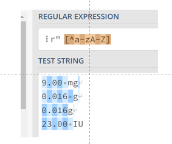

```python
#Replace this pattern [^a-zA-Z] with nothing
#We get a new df with all the numeric values removed and only units remaining
nutri.replace('[^a-zA-Z]' , '' , regex = True).head(5)
```

| name | serving_size | calories | total_fat | saturated_fat | cholesterol | sodium | choline | folate | folic_acid | niacin | ... | fat | saturated_fatty_acids | monounsaturated_fatty_acids | polyunsaturated_fatty_acids | fatty_acids_total_trans | alcohol | ash | caffeine | theobromine | water |
| --- | --- | --- | --- | --- | --- | --- | --- | --- | --- | --- | --- | --- | --- | --- | --- | --- | --- | --- | --- | --- | --- |
| Cornstarch | g | 381 | g | NaN |  | mg | mg | mcg | mcg | mg | ... | g | g | g | g | mg | g | g | mg | mg | g |
| Nuts, pecans | g | 691 | g | g |  | mg | mg | mcg | mcg | mg | ... | g | g | g | g | mg | g | g | mg | mg | g |
| Eggplant, raw | g | 25 | g | NaN |  | mg | mg | mcg | mcg | mg | ... | g | g | g | g | mg | g | g | mg | mg | g |
| Teff, uncooked | g | 367 | g | g |  | mg | mg |  |  | mg | ... | g | g | g | g |  |  | g |  |  | g |
| Sherbet, orange | g | 144 | g | g | mg | mg | mg | mcg | mcg | mg | ... | g | g | g | g | mg | g | g | mg | mg | g |

5 rows × 75 columns

- If you observe , the calories column is still untouched
- Since Calories was purely an int series
- A better way to deal with this is by casting the entire series to strings before we do our replacement
- nutri.astype(str)
- We will re-run the above code

```python
#Replace this pattern [^a-zA-Z] with nothing
#We get a new df with all the numeric values removed and only units remaining
nutri.astype(str).replace('[^a-zA-Z]' , '' , regex = True)
```

| name | serving_size | calories | total_fat | saturated_fat | cholesterol | sodium | choline | folate | folic_acid | niacin | ... | fat | saturated_fatty_acids | monounsaturated_fatty_acids | polyunsaturated_fatty_acids | fatty_acids_total_trans | alcohol | ash | caffeine | theobromine | water |
| --- | --- | --- | --- | --- | --- | --- | --- | --- | --- | --- | --- | --- | --- | --- | --- | --- | --- | --- | --- | --- | --- |
| Cornstarch | g |  | g | nan |  | mg | mg | mcg | mcg | mg | ... | g | g | g | g | mg | g | g | mg | mg | g |
| Nuts, pecans | g |  | g | g |  | mg | mg | mcg | mcg | mg | ... | g | g | g | g | mg | g | g | mg | mg | g |
| Eggplant, raw | g |  | g | nan |  | mg | mg | mcg | mcg | mg | ... | g | g | g | g | mg | g | g | mg | mg | g |
| Teff, uncooked | g |  | g | g |  | mg | mg |  |  | mg | ... | g | g | g | g |  |  | g |  |  | g |
| Sherbet, orange | g |  | g | g | mg | mg | mg | mcg | mcg | mg | ... | g | g | g | g | mg | g | g | mg | mg | g |
| ... | ... | ... | ... | ... | ... | ... | ... | ... | ... | ... | ... | ... | ... | ... | ... | ... | ... | ... | ... | ... | ... |
| Beef, raw, all grades, trimmed to 0" fat, separable lean and fat, boneless, top round roast, round | g |  | g | g | mg | mg | mg | mcg | mcg | mg | ... | g | g | g | g | mg | g | g | mg | mg | g |
| Lamb, cooked, separable lean only, composite of trimmed retail cuts, frozen, imported, New Zealand | g |  | g | g | mg | mg |  | mcg | mcg | mg | ... | g | g | g | g | mg |  | g |  |  | g |
| Lamb, raw, separable lean and fat, composite of trimmed retail cuts, frozen, imported, New Zealand | g |  | g | g | mg | mg |  | mcg | mcg | mg | ... | g | g | g | g | mg |  | g |  |  | g |
| Beef, raw, all grades, trimmed to 0" fat, separable lean only, boneless, eye of round roast, round | g |  | g | g | mg | mg | mg | mcg | mcg | mg | ... | g | g | g | g | mg | g | g | mg | mg | g |
| Beef, raw, all grades, trimmed to 0" fat, separable lean only, boneless, eye of round steak, round | g |  | g | g | mg | mg | mg | mcg | mcg | mg | ... | g | g | g | g | mg | g | g | mg | mg | g |

8789 rows × 75 columns

- So at this point we have a Dataframe of units only
- But we see lot of gaps here
- Like , sometimes there are no units , sometimes there are blanks etc

### Just for info

```python
x = np.NAN
```

```python
type(x)
```

```
float
```

```python
x
```

```
nan
```

- This is Numeric nan

```python
(str(x))
```

```
'nan'
```

```python
type(str(x))
```

```
str
```

- This is string nan

```python
#Lets assign this to a new var : "units"
units = nutri.astype(str).replace('[^a-zA-Z]' , '' , regex = True)
```

```python
#Lets look at the first five observations
units.head()
```

| name | serving_size | calories | total_fat | saturated_fat | cholesterol | sodium | choline | folate | folic_acid | niacin | ... | fat | saturated_fatty_acids | monounsaturated_fatty_acids | polyunsaturated_fatty_acids | fatty_acids_total_trans | alcohol | ash | caffeine | theobromine | water |
| --- | --- | --- | --- | --- | --- | --- | --- | --- | --- | --- | --- | --- | --- | --- | --- | --- | --- | --- | --- | --- | --- |
| Cornstarch | g |  | g | nan |  | mg | mg | mcg | mcg | mg | ... | g | g | g | g | mg | g | g | mg | mg | g |
| Nuts, pecans | g |  | g | g |  | mg | mg | mcg | mcg | mg | ... | g | g | g | g | mg | g | g | mg | mg | g |
| Eggplant, raw | g |  | g | nan |  | mg | mg | mcg | mcg | mg | ... | g | g | g | g | mg | g | g | mg | mg | g |
| Teff, uncooked | g |  | g | g |  | mg | mg |  |  | mg | ... | g | g | g | g |  |  | g |  |  | g |
| Sherbet, orange | g |  | g | g | mg | mg | mg | mcg | mcg | mg | ... | g | g | g | g | mg | g | g | mg | mg | g |

5 rows × 75 columns

- If you observe the "saturated_fat" column , we have 2 "nan" and 3 "g"

```python
#looking at the saturated_fat column alone
units.saturated_fat
```

```
name
Cornstarch                                                                                            nan
Nuts, pecans                                                                                            g
Eggplant, raw                                                                                         nan
Teff, uncooked                                                                                          g
Sherbet, orange                                                                                         g
                                                                                                     ...
Beef, raw, all grades, trimmed to 0" fat, separable lean and fat, boneless, top round roast, round      g
Lamb, cooked, separable lean only, composite of trimmed retail cuts, frozen, imported, New Zealand      g
Lamb, raw, separable lean and fat, composite of trimmed retail cuts, frozen, imported, New Zealand      g
Beef, raw, all grades, trimmed to 0" fat, separable lean only, boneless, eye of round roast, round      g
Beef, raw, all grades, trimmed to 0" fat, separable lean only, boneless, eye of round steak, round      g
Name: saturated_fat, Length: 8789, dtype: object
```

```python
units.saturated_fat.value_counts()
```

```
g      7199
nan    1590
Name: saturated_fat, dtype: int64
```

- We can see all the unique values in that Series
- We can see 1590 nan which could be probably from foods which do not contain "saturated fats" at all
- How can me keep the most common value from this column
- We use the mode()
- When we apply mode() to the Series , we get another series containing the most common observation

```python
units.saturated_fat.mode()
```

```
0    g
dtype: object
```

When we apply mode() to a DataFrame , we get another Dataframe , we get a DataFrame containing the values that shows up most frequently in each column

```python
units.mode()
```

|  | serving_size | calories | total_fat | saturated_fat | cholesterol | sodium | choline | folate | folic_acid | niacin | ... | fat | saturated_fatty_acids | monounsaturated_fatty_acids | polyunsaturated_fatty_acids | fatty_acids_total_trans | alcohol | ash | caffeine | theobromine | water |
| --- | --- | --- | --- | --- | --- | --- | --- | --- | --- | --- | --- | --- | --- | --- | --- | --- | --- | --- | --- | --- | --- |
| 0 | g |  | g | g | mg | mg | mg | mcg | mcg | mg | ... | g | g | g | g | mg | g | g | mg | mg | g |

1 rows × 75 columns

- This is what we wanted to see. We now know that
- Calories column has no units
- We can also see what units the other columns have

```python
#Lets assign this Df to tne 'units' variable
units = units.mode()
```

### The rename() method

Using rename() we will be able to change or rename our labels

Remember , our dataframe has two labeled dimensions : the Index and the Columns

- Lets first explore the rename() method in isolation before we use it at scale later (on the whole df)

```python
#Lets look at the df we created earlier
df
```

|  | age | weight | height |
| --- | --- | --- | --- |
| 0 | 12.0 | 41.1 | 1.72 |
| 1 | 13.0 | 34.5 | 1.74 |
| 2 | 14.0 | 83.2 | 1.91 |
| 3 | 16.0 | 90.1 | 1.54 |

```python
#Changing the Index label for the first row
df.rename(index = {0 : 'Pikachu'})
```

|  | age | weight | height |
| --- | --- | --- | --- |
| Pikachu | 12.0 | 41.1 | 1.72 |
| 1 | 13.0 | 34.5 | 1.74 |
| 2 | 14.0 | 83.2 | 1.91 |
| 3 | 16.0 | 90.1 | 1.54 |

```python
df.rename(index = {0 : 'Pikachu' , 1 : 'Andy'})
```

|  | age | weight | height |
| --- | --- | --- | --- |
| Pikachu | 12.0 | 41.1 | 1.72 |
| Andy | 13.0 | 34.5 | 1.74 |
| 2 | 14.0 | 83.2 | 1.91 |
| 3 | 16.0 | 90.1 | 1.54 |

```python
#rename Columns
df.rename(columns = {'weight' : 'weight (kg)'})
```

|  | age | weight (kg) | height |
| --- | --- | --- | --- |
| 0 | 12.0 | 41.1 | 1.72 |
| 1 | 13.0 | 34.5 | 1.74 |
| 2 | 14.0 | 83.2 | 1.91 |
| 3 | 16.0 | 90.1 | 1.54 |

```python
#Rename both index and column labels at once
df.rename(columns = {'weight' : 'weight (kg)'} , index = {0 : 'Pikachu'})
```

|  | age | weight (kg) | height |
| --- | --- | --- | --- |
| Pikachu | 12.0 | 41.1 | 1.72 |
| 1 | 13.0 | 34.5 | 1.74 |
| 2 | 14.0 | 83.2 | 1.91 |
| 3 | 16.0 | 90.1 | 1.54 |

```python
df
```

|  | age | weight | height |
| --- | --- | --- | --- |
| 0 | 12.0 | 41.1 | 1.72 |
| 1 | 13.0 | 34.5 | 1.74 |
| 2 | 14.0 | 83.2 | 1.91 |
| 3 | 16.0 | 90.1 | 1.54 |

```python
#Alternate way to rename is to use mapper()
#With mapper(), we would not be able to rename both column and index axes at once
#we can use axis = 'columns' also
df.rename(mapper = {'height' : 'Height (m)'}, axis = 1)
```

|  | age | weight | Height (m) |
| --- | --- | --- | --- |
| 0 | 12.0 | 41.1 | 1.72 |
| 1 | 13.0 | 34.5 | 1.74 |
| 2 | 14.0 | 83.2 | 1.91 |
| 3 | 16.0 | 90.1 | 1.54 |

```python
#We get the column axis
df.axes[1]
```

```
Index(['age', 'weight', 'height'], dtype='object')
```

```python
nutri.axes[1][0] #getting the First column
```

```
'serving_size'
```

```python
nutri.axes[1][-1] #getting the Last column
```

```
'water'
```

```python
#axes = 0 gives us the Index labels
df.axes[0]
```

```
RangeIndex(start=0, stop=4, step=1)
```

```python
nutri.axes[0]
```

```
Index(['Cornstarch', 'Nuts, pecans', 'Eggplant, raw', 'Teff, uncooked',
       'Sherbet, orange', 'Cauliflower, raw', 'Taro leaves, raw',
       'Lamb, raw, ground', 'Cheese, camembert', 'Vegetarian fillets',
       ...
       'Beef, braised, cooked, all grades, trimmed to 1/8" fat, separable lean and fat, flat half, brisket',
       'Beef, raw, select, trimmed to 1/8" fat, separable lean only, lip-on, boneless, rib eye steak/roast',
       'Beef, raw, choice, trimmed to 1/8" fat, separable lean only, lip-on, boneless, rib eye steak/roast',
       'Oil, uses similar to 95 degree hard butter, confection fat, palm kernel (hydrogenated), industrial',
       'Beef, raw, all grades, trimmed to 0" fat, separable lean and fat, boneless, top round steak, round',
       'Beef, raw, all grades, trimmed to 0" fat, separable lean and fat, boneless, top round roast, round',
       'Lamb, cooked, separable lean only, composite of trimmed retail cuts, frozen, imported, New Zealand',
       'Lamb, raw, separable lean and fat, composite of trimmed retail cuts, frozen, imported, New Zealand',
       'Beef, raw, all grades, trimmed to 0" fat, separable lean only, boneless, eye of round roast, round',
       'Beef, raw, all grades, trimmed to 0" fat, separable lean only, boneless, eye of round steak, round'],
      dtype='object', name='name', length=8789)
```

### DataFrame .dropna()

dropna() method excludes all null values from given Series

- In DataFrames we need to specify the axis

```python
df
```

|  | age | weight | height |
| --- | --- | --- | --- |
| 0 | 12.0 | 41.1 | 1.72 |
| 1 | 13.0 | 34.5 | 1.74 |
| 2 | 14.0 | 83.2 | 1.91 |
| 3 | 16.0 | 90.1 | 1.54 |

https://www.udemy.com/course/the-ultimate-pandas-bootcamp-advanced-python-data-analysis/learn/lecture/18639862#overview

```python
#currently it does not have a null value ,lets insert
df.loc[2, 'weight'] = np.nan
```

```python
df
```

|  | age | weight | height |
| --- | --- | --- | --- |
| 0 | 12.0 | 41.1 | 1.72 |
| 1 | 13.0 | 34.5 | 1.74 |
| 2 | 14.0 | NaN | 1.91 |
| 3 | 16.0 | 90.1 | 1.54 |

```python
#Row : 1 and all columns
df.loc[1 , :] = np.nan
```

```python
df
```

|  | age | weight | height |
| --- | --- | --- | --- |
| 0 | 12.0 | 41.1 | 1.72 |
| 1 | NaN | NaN | NaN |
| 2 | 14.0 | NaN | 1.91 |
| 3 | 16.0 | 90.1 | 1.54 |

```python
#Now we have atleast one NAN in each column
```

```python
#dropna() without specifying the axis
#it works exactly as df.dropna(how = 'any' , axis = 0)
#default is the Row axis
df.dropna()
```

|  | age | weight | height |
| --- | --- | --- | --- |
| 0 | 12.0 | 41.1 | 1.72 |
| 3 | 16.0 | 90.1 | 1.54 |

- All NANs from any row and column got removed
- Row 1 and Row 2 is completely gone

```python
#axis = 0 is for Rows
df.dropna(how = 'any' , axis = 0)
```

|  | age | weight | height |
| --- | --- | --- | --- |
| 0 | 12.0 | 41.1 | 1.72 |
| 3 | 16.0 | 90.1 | 1.54 |

For axis = 0 (Row)

- how = all : Drop rows only if all values in the Rows are Null
- how = any : Drop rows only if any value in the Rows is Null

For axis = 1 (Column)

- how = all : Drop Columns only if all values in the columns are Null
- how = any : Drop Columns only if any value in the columns is Null

```python
#axis = 1 is for columns
df.dropna(how = 'any' , axis = 1)
```

| 0 |
| --- |
| 1 |
| 2 |
| 3 |

```python
#axis = 0 is for rows
df.dropna(how = 'all' , axis = 0)
```

|  | age | weight | height |
| --- | --- | --- | --- |
| 0 | 12.0 | 41.1 | 1.72 |
| 2 | 14.0 | NaN | 1.91 |
| 3 | 16.0 | 90.1 | 1.54 |

```python
#axis = 1 is for columns
df.dropna(how = 'all' , axis = 1)
```

|  | age | weight | height |
| --- | --- | --- | --- |
| 0 | 12.0 | 41.1 | 1.72 |
| 1 | NaN | NaN | NaN |
| 2 | 14.0 | NaN | 1.91 |
| 3 | 16.0 | 90.1 | 1.54 |

```python
how parameter allows us to set a condition as to what should be dropped or excluded
```

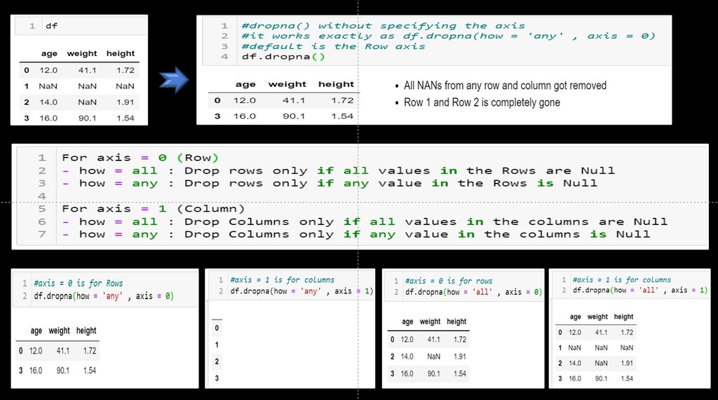